# TEAM Academy Charter School — NJ School Data Almanac – NJ District Profiles

NJ School Data Almanac

TEAM Academy Charter School

ESSEX COUNTY · CHARTER DISTRICT · no DFG · 6,600 STUDENTS (2026)

6,600

Students

88.6%

4-yr grad rate

38.5%

Gr 3-8 ELA

37.7%

Chronically absent

*9 things the data says about TEAM Academy Charter School. Every figure is computed from New Jersey Department of Education data via the njschooldata package — nothing is estimated. Comparisons use District Factor Group (DFG) peers.*

No. 1 ACHIEVEMENT

## TEAM Academy’s Grades 3-8 Reading Lost 17 Points to COVID and Is Still 13 Points Below Its 2019 Mark

Elementary and middle-school ELA proficiency fell from 51.6% before the pandemic to 34.4% in 2022 and has recovered to only 38.5% by 2024.

Before the pandemic, more than half of TEAM Academy’s third- through eighth-graders read at grade level: NJSLA English language arts proficiency stood at 51.6 percent in 2019. The pandemic erased much of that. By 2022 the rate had fallen to 34.4 percent, a drop of 17.2 percentage points in the network’s youngest tested students.

The climb back has been slow. ELA proficiency edged up to 38.8 percent in 2023 and then essentially stalled at 38.5 percent in 2024, still 13.1 points beneath the 2019 baseline. Put differently, after two years of recovery the network has regained only about a quarter of what the pandemic took from its grade 3-8 readers.

That plateau matters because these are the students who will fill TEAM Academy’s high-school grades over the next several years, where its NJGPA ELA proficiency already runs near 74 percent. With early-grades reading recovery appearing to flatten well short of where it started, can the network reaccelerate before this cohort moves up, or has 2019 become a ceiling rather than a floor?

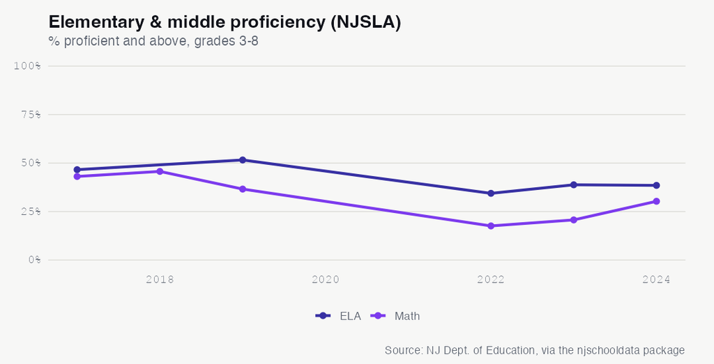

See the underlying data ›

No. 2 ATTENDANCE

## Chronic Absenteeism at TEAM Academy Hit 55% in 2022 and Remains 17 Points Above Its 2019 Level

More than half the network’s students were chronically absent at the pandemic peak; the 2024 rate of 37.7% is still nearly double 2019.

Before the pandemic, about one in five TEAM Academy students was chronically absent, a rate of 20.9 percent in 2019. COVID detonated that number. By 2022, 55.1 percent of students were chronically absent, meaning more than half missed roughly a tenth or more of the school year.

The network has clawed back since, to 48.1 percent in 2023 and 37.7 percent in 2024. But the 2024 figure is still 16.8 points above the 2019 baseline and nearly double the pre-pandemic rate, even as the network’s enrollment kept climbing to record highs.

Chronic absenteeism is one of the strongest early-warning signs in education, and it tracks closely with TEAM Academy’s stalled grade 3-8 test recovery. With more than one in three students still missing significant instruction, how much of the academic plateau is an attendance problem in disguise, and can the network return to its 2019 levels before the gap calcifies?

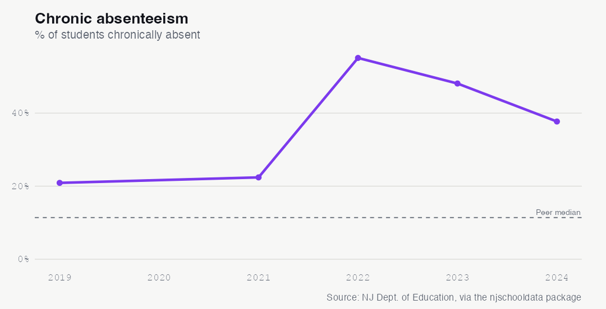

See the underlying data ›

No. 3 EQUITY

## TEAM Academy’s Students With Disabilities Reached Just 5.9% Proficiency in Reading, vs 49% for Peers Without Disadvantage

In 2024, fewer than 1 in 16 of the network’s grade 3-8 students with disabilities read at grade level, against a 38.5% overall rate.

TEAM Academy’s 2024 grade 3-8 reading results show a chasm by student group. Among students in special education, just 5.9 percent reached proficiency on the NJSLA, and students receiving special-education accommodations were close behind at 7.0 percent. The network’s overall rate was 38.5 percent, and students not classified as economically disadvantaged reached 49.2 percent.

Other gaps were narrower but present. Female students reached 45.1 percent proficiency against 28.3 percent for male students, a 16.8-point gender gap. Hispanic students (42.8 percent) and students who are economically disadvantaged (36.9 percent) clustered closer to the total, while current multilingual learners reached 33.3 percent.

The special-education gap stands apart in scale: a student with disabilities was roughly one-eighth as likely to read at grade level as a peer without economic disadvantage. As TEAM Academy works to recover from pandemic learning loss, what targeted supports could close a reading gap this wide for the network’s most vulnerable readers?

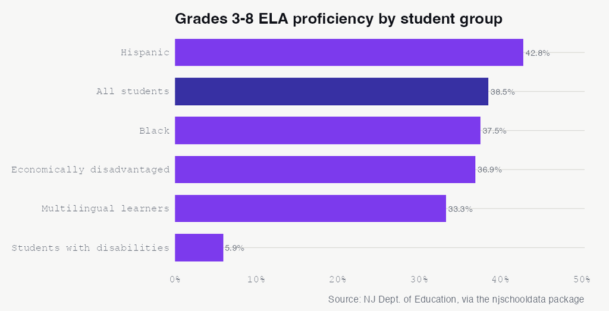

See the underlying data ›

No. 4 ACHIEVEMENT

## TEAM Academy’s Grades 3-8 Math Proficiency Has Recovered 13 Points Since 2022, From 17.6% to 30.3%

After the pandemic cut math proficiency to under 1 in 5, the network has rebuilt faster in math than in reading.

If reading recovery has stalled at TEAM Academy, math is the brighter line. NJSLA math proficiency for grades 3-8 cratered during the pandemic, falling to 17.6 percent in 2022, when fewer than one in five students performed at grade level. Since then it has rebuilt to 20.7 percent in 2023 and 30.3 percent in 2024, a two-year gain of 12.7 points.

That recovery has not fully erased the damage. The 2024 rate of 30.3 percent still sits below the 36.6 percent recorded in 2019, but the trajectory is steeper and more consistent than the ELA line, which barely moved between 2023 and 2024. Math, in other words, fell harder during COVID but is climbing back faster.

The pattern mirrors what played out at the high-school level, where NJGPA math proficiency nearly doubled to 39.5 percent in 2025. As the network pushes its grade 3-8 math line back toward 2019, can it apply whatever is driving the math rebound to its flatter reading results?

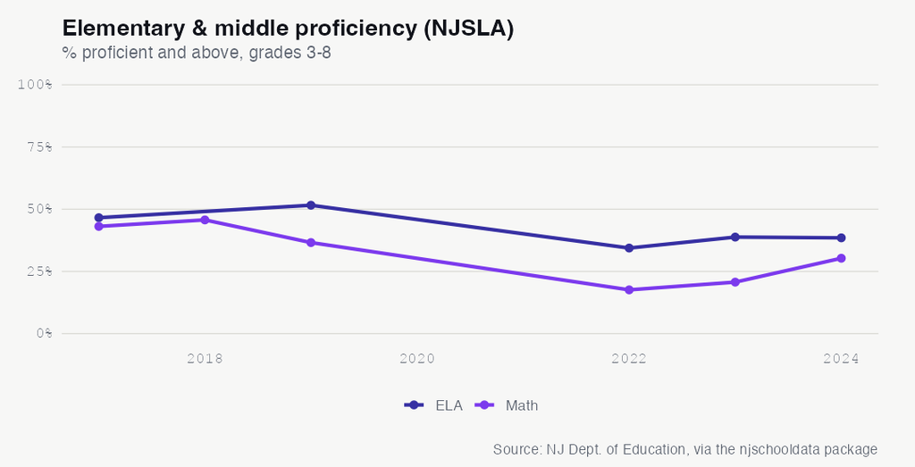

See the underlying data ›

No. 5 ENROLLMENT

## TEAM Academy’s Enrollment More Than Doubled to 6,600 Students Since 2015, a 142% Climb

The Newark KIPP charter network added nearly 3,900 students over the period and is now at its all-time peak.

TEAM Academy Charter School has grown faster than almost any traditional district could. In 2015 the Newark-based KIPP network enrolled 2,729 students. By 2026 it served 6,600, an increase of 3,871 students, or 141.8 percent, and its highest enrollment on record.

The growth was relentless rather than sudden. The network added between 300 and 520 students in every year from 2016 through 2023, then continued climbing more gradually, adding 223 students in 2024, 87 in 2025, and 194 in 2026. There is not a single down year in the twelve-year record. Even through the pandemic, the network grew nearly 30 percent, from 4,374 students in 2019 to 5,671 in 2022.

That expansion stands out because it coincided with a period when many New Jersey districts were losing students. As TEAM Academy now sits at its enrollment ceiling, the question for Newark families and the network’s board is whether the pace of new seats can keep matching demand, or whether the era of double-digit annual growth has given way to a plateau.

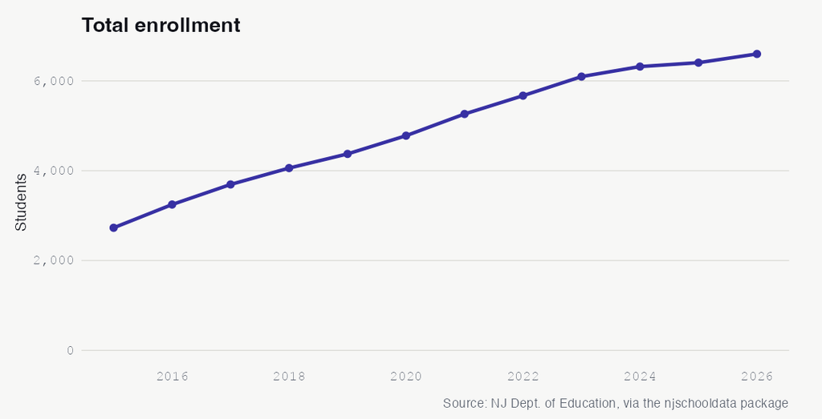

See the underlying data ›

No. 6 DEMOGRAPHICS

## TEAM Academy’s Black Enrollment Share Fell From 94% to 76% Since 2015 as Hispanic Enrollment Tripled

An almost entirely Black student body in 2015 has steadily diversified, with the Hispanic share rising nearly 12 points.

When TEAM Academy’s record opens in 2015, its student body was nearly uniform: 93.7 percent of students were Black and just 5.9 percent were Hispanic. By 2026 the Black share had fallen to 75.9 percent, a drop of 17.8 percentage points and the network’s single largest demographic change over the period.

The space was filled by two groups. The Hispanic share rose from 5.9 percent to 17.5 percent, an increase of 11.7 points that roughly tripled its representation. The multiracial share, essentially absent in 2015, grew to 6.0 percent by 2026, a gain of 5.9 points. White, Asian, and other groups together still account for well under one percent of enrollment.

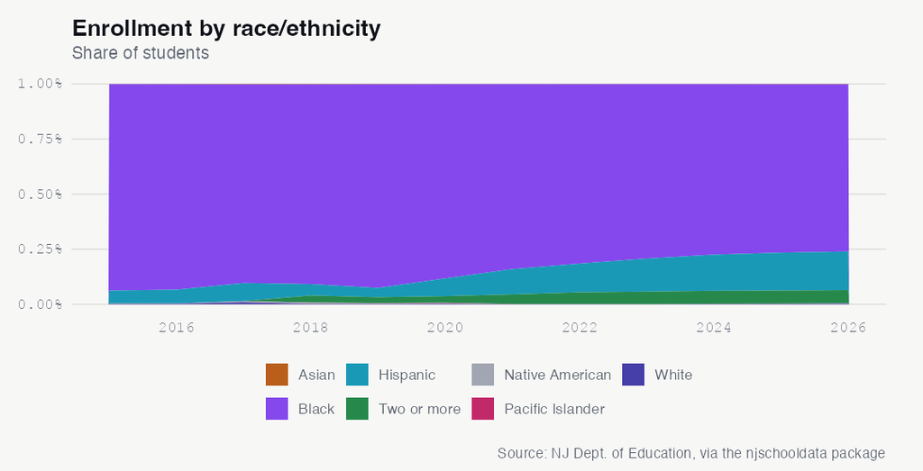

See the underlying data ›

No. 7 GRADUATION

## TEAM Academy’s Graduation Rate Slipped to 88.6% in 2025, Down From a 95.5% Peak in 2022

The four-year rate has fallen for three straight years even as the graduating cohort grew to 308 students.

TEAM Academy’s four-year graduation rate reached 95.5 percent in 2022, but it has receded every year since. The rate fell to 93.8 percent in 2023, 91.9 percent in 2024, and 88.6 percent in 2025, a decline of 6.9 points from the peak and the network’s lowest mark in the six years of available data.

The slide came as the graduating cohort kept growing, from 202 students in 2022 to 308 in 2025. A larger cohort can be harder to carry across the finish line, but the direction is consistent: three consecutive years of decline after the 2022 high.

The earliest year on record, 2020, shows a 90.0 percent rate, meaning the network is now graduating a slightly smaller share of students than it did at the start of the window even as it has scaled dramatically. As the cohorts get larger, can TEAM Academy reverse the recent downward trend and return to the mid-90s it reached in 2022?

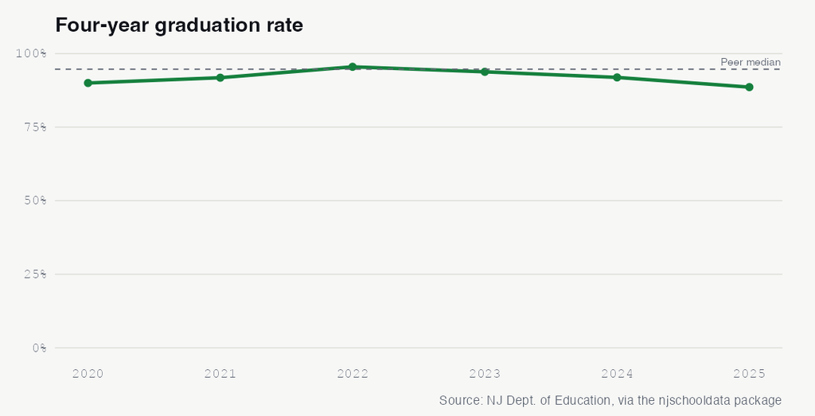

See the underlying data ›

No. 8 EQUITY

## TEAM Academy’s Multilingual Learners Graduated at 100% in 2025, While Boys Trailed Girls by Nearly 9 Points

Every one of the network’s 18 English-learner graduates finished on time, even as a gender gap and a disability gap persisted.

TEAM Academy’s 2025 graduation data leads with a striking success: all 18 of its multilingual learners in the cohort graduated, a 100 percent rate that topped every other tracked group and exceeded the network’s overall rate of 88.6 percent.

The lowest rate belonged to students with disabilities, at 83.0 percent for a group of 47, more than five points below the network total. With multilingual learners outperforming every other group while boys and students with disabilities lag, can TEAM Academy extend whatever is working for its English learners to the students still finishing behind?

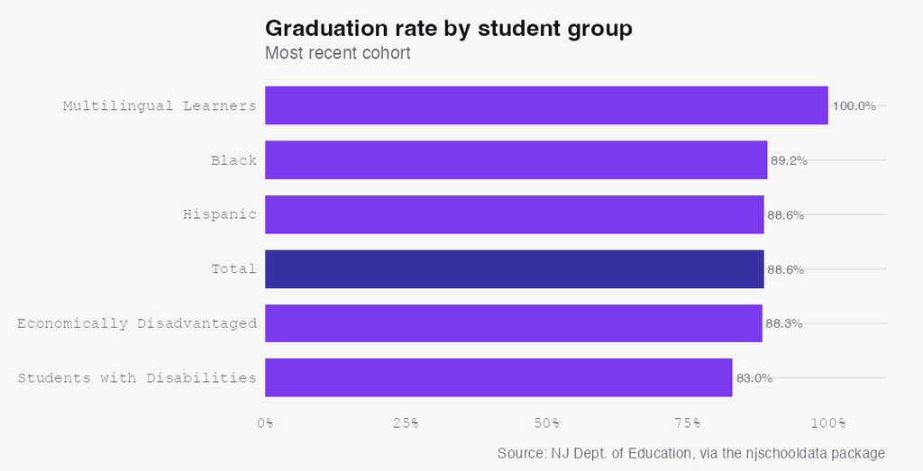

See the underlying data ›

No. 9 DEMOGRAPHICS

## TEAM Academy’s English-Learner Enrollment Grew From Zero to 343 Students as Economic Need Stayed Near 90%

A network that served no English learners in 2015 now classifies more than 5 percent of students as multilingual learners.

TEAM Academy recorded zero English learners in 2015. By 2026 the network served 343 students classified as multilingual learners, 5.2 percent of enrollment, a population that materialized and grew steadily over the decade.

The rise was incremental but consistent: from 73 students in 2019, to 177 in 2023, to 240 in 2024, to 343 in 2026. That trajectory mirrors the network’s broader demographic shift, as the Hispanic share of enrollment climbed from 5.9 percent to 17.5 percent over the same period. Economic need stayed consistently high throughout, with free or reduced-price lunch eligibility ranging from 86 to 93 percent and standing at 88.0 percent in 2026.

English learners were also TEAM Academy’s top-graduating group in 2025, finishing at 100 percent. As the multilingual population continues to grow alongside the Hispanic student body, can the network’s language supports scale fast enough to keep producing those outcomes for a group that did not exist in its classrooms a decade ago?

See the underlying data ›

## The Almanac

The full longitudinal record behind the stories above. Every number a reader can check.

### Enrollment (total)

| year | students | yoy | yoy_pct |
| --- | --- | --- | --- |
| 2015 | 2729 | NA | NA |
| 2016 | 3247 | 518 | 19 |
| 2017 | 3694 | 447 | 13.8 |
| 2018 | 4059 | 365 | 9.9 |
| 2019 | 4374 | 315 | 7.8 |
| 2020 | 4780 | 406 | 9.3 |
| 2021 | 5263 | 483 | 10.1 |
| 2022 | 5671 | 408 | 7.8 |
| 2023 | 6096 | 425 | 7.5 |
| 2024 | 6319 | 223 | 3.7 |
| 2025 | 6406 | 87 | 1.4 |
| 2026 | 6600 | 194 | 3 |

### Demographic share (%) by year

| end_year | white | black | hispanic | asian | native_american | pacific_islander | multiracial |
| --- | --- | --- | --- | --- | --- | --- | --- |
| 2015 | 0.2 | 93.7 | 5.9 | 0.1 | 0.1 | 0 | 0.1 |
| 2016 | 0.3 | 93.3 | 6.2 | 0.1 | 0.1 | 0 | 0 |
| 2017 | 0.9 | 90.2 | 8.2 | 0.2 | 0.5 | 0 | 0 |
| 2018 | 0.2 | 90.7 | 5.2 | 0.1 | 0.5 | 0.1 | 3.2 |
| 2019 | 0.2 | 92.5 | 4.2 | 0.1 | 0.4 | 0.1 | 2.6 |
| 2020 | 0.3 | 88.2 | 8.1 | 0.1 | 0.3 | 0.2 | 3 |
| 2021 | 0.1 | 84 | 11.5 | 0.1 | 0 | 0 | 4.4 |
| 2022 | 0.1 | 81.4 | 13 | 0.1 | 0 | 0 | 5.3 |
| 2023 | 0.1 | 79.2 | 15 | 0 | 0 | 0 | 5.7 |
| 2024 | 0.2 | 77.4 | 16.4 | 0.1 | 0.1 | 0 | 5.9 |
| 2025 | 0.2 | 76.5 | 17.2 | 0.1 | 0.1 | 0 | 5.9 |
| 2026 | 0.3 | 75.9 | 17.5 | 0.1 | 0.1 | 0 | 6 |

### Special populations (LEP, FRL)

| end_year | subgroup | students | pct |
| --- | --- | --- | --- |
| 2015 | lep | 0 | 0.0 |
| 2015 | free_reduced_lunch | 2398 | 87.9 |
| 2016 | lep | 8 | 0.2 |
| 2016 | free_reduced_lunch | 2850 | 87.8 |
| 2017 | lep | 8 | 0.2 |
| 2017 | free_reduced_lunch | 3253 | 88.1 |
| 2018 | lep | 12 | 0.3 |
| 2018 | free_reduced_lunch | 3584 | 88.3 |
| 2019 | lep | 73 | 1.7 |
| 2019 | free_reduced_lunch | 3845 | 87.9 |
| 2020 | lep | 76 | 1.6 |
| 2020 | free_reduced_lunch | 4140 | 86.6 |
| 2021 | lep | 89 | 1.7 |
| 2021 | free_reduced_lunch | 4510 | 85.7 |
| 2022 | lep | 102 | 1.8 |
| 2022 | free_reduced_lunch | 5070 | 89.4 |
| 2023 | lep | 177 | 2.9 |
| 2023 | free_reduced_lunch | 5401 | 88.6 |
| 2024 | lep | 240 | 3.8 |
| 2024 | free_reduced_lunch | 5693 | 90.1 |
| 2025 | lep | 314 | 4.9 |
| 2025 | free_reduced_lunch | 5945 | 92.8 |
| 2026 | lep | 343 | 5.2 |
| 2026 | free_reduced_lunch | 5808 | 88.0 |

### Graduation rate 4yr (total)

| year | grad_rate | cohort |
| --- | --- | --- |
| 2020 | 90 | 170 |
| 2021 | 91.8 | 220 |
| 2022 | 95.5 | 202 |
| 2023 | 93.8 | 289 |
| 2024 | 91.9 | 296 |
| 2025 | 88.6 | 308 |

### Graduation by subgroup (2025)

| subgroup | grad_rate | cohort |
| --- | --- | --- |
| multilingual learners | 100.0 | 18 |
| female | 93.2 | 147 |
| black | 89.2 | 240 |
| total | 88.6 | 308 |
| hispanic | 88.6 | 44 |
| economically disadvantaged | 88.3 | 291 |
| students experiencing homelessness | 88.2 | 51 |
| male | 84.5 | 161 |
| multiracial | 83.3 | 24 |
| students with disabilities | 83.0 | 47 |
| american indian | NA | NA |
| asian | NA | NA |
| migrant students | NA | NA |
| military-connected students | NA | NA |
| non-binary/undesignated gender | NA | NA |
| students in foster care | NA | NA |
| white | NA | NA |

### NJGPA high-school proficiency (% proficient+)

| year | test | prof_above | valid |
| --- | --- | --- | --- |
| 2023 | ela | 68.6 | 274 |
| 2023 | math | 22.4 | 277 |
| 2024 | ela | 74.6 | 295 |
| 2024 | math | 21.2 | 297 |
| 2025 | ela | 74.1 | 320 |
| 2025 | math | 39.5 | 319 |

### NJGPA ELA by subgroup (2025)

[output not shown]

### NJSLA grades 3-8 proficiency (% proficient+, enrollment-weighted across grades)

| testing_year | test_name | prof |
| --- | --- | --- |
| 2017 | ela | 46.6 |
| 2017 | math | 43.1 |
| 2018 | math | 45.7 |
| 2019 | ela | 51.6 |
| 2019 | math | 36.6 |
| 2022 | ela | 34.4 |
| 2022 | math | 17.6 |
| 2023 | ela | 38.8 |
| 2023 | math | 20.7 |
| 2024 | ela | 38.5 |
| 2024 | math | 30.3 |

### NJSLA ELA proficiency by subgroup (2024, grades 3-8)

| subgroup | prof |
| --- | --- |
| non_ed | 49.2 |
| FORMER - ML | 45.5 |
| female | 45.1 |
| hispanic | 42.8 |
| other | 42.6 |
| total_population | 38.5 |
| black | 37.5 |
| ed | 36.9 |
| lep_current_former | 36.7 |
| CURRENT - ML | 33.3 |
| male | 28.3 |
| MULTILINGUAL LEARNERS | 25.8 |
| sped_accomodations | 7.0 |
| special_education | 5.9 |
| lep_current | NA |

### Chronic absenteeism (% chronically absent)

| year | chronic_pct |
| --- | --- |
| 2019 | 20.9 |
| 2021 | 22.4 |
| 2022 | 55.1 |
| 2023 | 48.1 |
| 2024 | 37.7 |

### Disciplinary removals

[output not shown]

### Police notifications (incident counts)

| year | violence | weapons | vandalism | substances | hib | other |
| --- | --- | --- | --- | --- | --- | --- |
| 2019 | 0 | 0 | 0 | 0 | 0 | 3 |
| 2020 | 0 | 1 | 0 | 2 | 0 | 3 |
| 2021 | 0 | 0 | 0 | 0 | 0 | 0 |
| 2022 | 6 | 2 | 0 | 2 | 0 | 2 |
| 2023 | 2 | 2 | 0 | 5 | 0 | 2 |
| 2024 | 6 | 5 | 2 | 22 | 0 | 18 |

### HIB (harassment/intimidation/bullying) investigations

| end_year | alleged | confirmed |
| --- | --- | --- |
| 2019 | 18 | 2 |
| 2020 | 18 | 2 |
| 2021 | 3 | 0 |
| 2022 | 30 | 26 |
| 2023 | 38 | 26 |
| 2024 | 17 | 18 |

### SAT participation (% of grade)

| year | sat_part | state_sat |
| --- | --- | --- |
| 2018 | 77.3 | 72.2 |
| 2019 | 12.1 | 72.1 |
| 2020 | 10.4 | 71.1 |
| 2021 | 2.9 | 45.4 |
| 2022 | 2.6 | 60.8 |
| 2023 | 1.8 | 61.9 |
| 2024 | 0.4 | 62.7 |

### AP/IB & dual enrollment (% of students)

| year | apib_coursework | apib_exam | ap3_ib4 | state_ap3_ib4 | dual |
| --- | --- | --- | --- | --- | --- |
| 2018 | 48.4 | 45.9 | 7.5 | 20.5 | 0 |
| 2019 | 74.2 | 48.4 | 5.3 | 20.7 | 0 |
| 2020 | 89.3 | 74.2 | 19.5 | 22.8 | 0 |
| 2021 | 91.1 | 60 | NA | 17.9 | 0 |
| 2022 | 82.1 | 73.5 | NA | 19.9 | 0 |
| 2023 | 39 | 29.3 | NA | 21.3 | 33.7 |
| 2024 | 42.4 | 33.6 | NA | 23 | 18.6 |

### Special education (raw rows; inspect for classification rate)

[output not shown]

### Staffing ratios

| end_year | student_teacher_district | student_admin_district | student_counselor_district | student_nurse_district |
| --- | --- | --- | --- | --- |
| 2024 | 23:1 | NA | NA | 6241:1 |

Back to top